# Week 6 | Data Transformation

Krishna Chaitanya Kundety

June 2, 2019

```r
library(nycflights13)
library(tidyverse)
library(car)
library(knitr)

knitr::opts_chunk$set(cache = TRUE)
```

## 5.2.4 Exercises

### 1. Find all flights that:

#### 1.1 Had an arrival delay of two or more hours.

```r
delay_ge2hrs <- flights %>%
  filter(arr_delay >= 120) %>%
  select(flight, arr_delay)

kable(head(delay_ge2hrs), longtable=T)
```

| flight | arr_delay |
| --- | --- |
| 4576 | 137 |
| 3944 | 851 |
| 856 | 123 |
| 1086 | 145 |
| 4497 | 127 |
| 525 | 125 |

#### 1.2 Flew to Houston (IAH or HOU).

```r
houston <- flights %>%
  filter(dest %in% c("IAH", "HOU"))

kable(head(houston))
```

| year | month | day | dep_time | sched_dep_time | dep_delay | arr_time | sched_arr_time | arr_delay | carrier | flight | tailnum | origin | dest | air_time | distance | hour | minute | time_hour |
| --- | --- | --- | --- | --- | --- | --- | --- | --- | --- | --- | --- | --- | --- | --- | --- | --- | --- | --- |
| 2013 | 1 | 1 | 517 | 515 | 2 | 830 | 819 | 11 | UA | 1545 | N14228 | EWR | IAH | 227 | 1400 | 5 | 15 | 2013-01-01 05:00:00 |
| 2013 | 1 | 1 | 533 | 529 | 4 | 850 | 830 | 20 | UA | 1714 | N24211 | LGA | IAH | 227 | 1416 | 5 | 29 | 2013-01-01 05:00:00 |
| 2013 | 1 | 1 | 623 | 627 | -4 | 933 | 932 | 1 | UA | 496 | N459UA | LGA | IAH | 229 | 1416 | 6 | 27 | 2013-01-01 06:00:00 |
| 2013 | 1 | 1 | 728 | 732 | -4 | 1041 | 1038 | 3 | UA | 473 | N488UA | LGA | IAH | 238 | 1416 | 7 | 32 | 2013-01-01 07:00:00 |
| 2013 | 1 | 1 | 739 | 739 | 0 | 1104 | 1038 | 26 | UA | 1479 | N37408 | EWR | IAH | 249 | 1400 | 7 | 39 | 2013-01-01 07:00:00 |
| 2013 | 1 | 1 | 908 | 908 | 0 | 1228 | 1219 | 9 | UA | 1220 | N12216 | EWR | IAH | 233 | 1400 | 9 | 8 | 2013-01-01 09:00:00 |

#### 1.3 Were operated by United, American, or Delta.

```r
ua_aa_dl <- flights %>%
  filter(carrier %in% c("AA", "DL", "UA"))

kable(head(ua_aa_dl))
```

| year | month | day | dep_time | sched_dep_time | dep_delay | arr_time | sched_arr_time | arr_delay | carrier | flight | tailnum | origin | dest | air_time | distance | hour | minute | time_hour |
| --- | --- | --- | --- | --- | --- | --- | --- | --- | --- | --- | --- | --- | --- | --- | --- | --- | --- | --- |
| 2013 | 1 | 1 | 517 | 515 | 2 | 830 | 819 | 11 | UA | 1545 | N14228 | EWR | IAH | 227 | 1400 | 5 | 15 | 2013-01-01 05:00:00 |
| 2013 | 1 | 1 | 533 | 529 | 4 | 850 | 830 | 20 | UA | 1714 | N24211 | LGA | IAH | 227 | 1416 | 5 | 29 | 2013-01-01 05:00:00 |
| 2013 | 1 | 1 | 542 | 540 | 2 | 923 | 850 | 33 | AA | 1141 | N619AA | JFK | MIA | 160 | 1089 | 5 | 40 | 2013-01-01 05:00:00 |
| 2013 | 1 | 1 | 554 | 600 | -6 | 812 | 837 | -25 | DL | 461 | N668DN | LGA | ATL | 116 | 762 | 6 | 0 | 2013-01-01 06:00:00 |
| 2013 | 1 | 1 | 554 | 558 | -4 | 740 | 728 | 12 | UA | 1696 | N39463 | EWR | ORD | 150 | 719 | 5 | 58 | 2013-01-01 05:00:00 |
| 2013 | 1 | 1 | 558 | 600 | -2 | 753 | 745 | 8 | AA | 301 | N3ALAA | LGA | ORD | 138 | 733 | 6 | 0 | 2013-01-01 06:00:00 |

#### 1.4 Departed in summer (July, August, and September).

```r
summer <- flights %>% filter(month %in% 7:9)

kable(head(summer))
```

| year | month | day | dep_time | sched_dep_time | dep_delay | arr_time | sched_arr_time | arr_delay | carrier | flight | tailnum | origin | dest | air_time | distance | hour | minute | time_hour |
| --- | --- | --- | --- | --- | --- | --- | --- | --- | --- | --- | --- | --- | --- | --- | --- | --- | --- | --- |
| 2013 | 7 | 1 | 1 | 2029 | 212 | 236 | 2359 | 157 | B6 | 915 | N653JB | JFK | SFO | 315 | 2586 | 20 | 29 | 2013-07-01 20:00:00 |
| 2013 | 7 | 1 | 2 | 2359 | 3 | 344 | 344 | 0 | B6 | 1503 | N805JB | JFK | SJU | 200 | 1598 | 23 | 59 | 2013-07-01 23:00:00 |
| 2013 | 7 | 1 | 29 | 2245 | 104 | 151 | 1 | 110 | B6 | 234 | N348JB | JFK | BTV | 66 | 266 | 22 | 45 | 2013-07-01 22:00:00 |
| 2013 | 7 | 1 | 43 | 2130 | 193 | 322 | 14 | 188 | B6 | 1371 | N794JB | LGA | FLL | 143 | 1076 | 21 | 30 | 2013-07-01 21:00:00 |
| 2013 | 7 | 1 | 44 | 2150 | 174 | 300 | 100 | 120 | AA | 185 | N324AA | JFK | LAX | 297 | 2475 | 21 | 50 | 2013-07-01 21:00:00 |
| 2013 | 7 | 1 | 46 | 2051 | 235 | 304 | 2358 | 186 | B6 | 165 | N640JB | JFK | PDX | 304 | 2454 | 20 | 51 | 2013-07-01 20:00:00 |

#### 1.5 Arrived more than two hours late, but didn’t leave late.

```r
late_arr_dep_ontime <- flights %>%
  filter(arr_delay > 120, dep_delay <= 0)

kable(head(late_arr_dep_ontime))
```

| year | month | day | dep_time | sched_dep_time | dep_delay | arr_time | sched_arr_time | arr_delay | carrier | flight | tailnum | origin | dest | air_time | distance | hour | minute | time_hour |
| --- | --- | --- | --- | --- | --- | --- | --- | --- | --- | --- | --- | --- | --- | --- | --- | --- | --- | --- |
| 2013 | 1 | 27 | 1419 | 1420 | -1 | 1754 | 1550 | 124 | MQ | 3728 | N1EAMQ | EWR | ORD | 135 | 719 | 14 | 20 | 2013-01-27 14:00:00 |
| 2013 | 10 | 7 | 1350 | 1350 | 0 | 1736 | 1526 | 130 | EV | 5181 | N611QX | LGA | MSN | 117 | 812 | 13 | 50 | 2013-10-07 13:00:00 |
| 2013 | 10 | 7 | 1357 | 1359 | -2 | 1858 | 1654 | 124 | AA | 1151 | N3CMAA | LGA | DFW | 192 | 1389 | 13 | 59 | 2013-10-07 13:00:00 |
| 2013 | 10 | 16 | 657 | 700 | -3 | 1258 | 1056 | 122 | B6 | 3 | N703JB | JFK | SJU | 225 | 1598 | 7 | 0 | 2013-10-16 07:00:00 |
| 2013 | 11 | 1 | 658 | 700 | -2 | 1329 | 1015 | 194 | VX | 399 | N629VA | JFK | LAX | 336 | 2475 | 7 | 0 | 2013-11-01 07:00:00 |
| 2013 | 3 | 18 | 1844 | 1847 | -3 | 39 | 2219 | 140 | UA | 389 | N560UA | JFK | SFO | 386 | 2586 | 18 | 47 | 2013-03-18 18:00:00 |

#### 1.6 Were delayed by at least an hour, but made up over 30 minutes in flight.

```r
# If there is a  dep_delay of 10 minutes  then arr_delay should be 10 - 10 = 0, so air time was on time.

# If dep_delay is 10 minutes late but arr_delay  is -30 minutes earlier, then arr_delay SHOULD'VE been 10 but instead is -30 (because of 30 catch up), so 10 - (-30) = 20.
filter(flights, dep_delay >= 60, (dep_delay - arr_delay > 30))
```

```
## # A tibble: 1,844 x 19
##     year month   day dep_time sched_dep_time dep_delay arr_time
##    <int> <int> <int>    <int>          <int>     <dbl>    <int>
##  1  2013     1     1     2205           1720       285       46
##  2  2013     1     1     2326           2130       116      131
##  3  2013     1     3     1503           1221       162     1803
##  4  2013     1     3     1839           1700        99     2056
##  5  2013     1     3     1850           1745        65     2148
##  6  2013     1     3     1941           1759       102     2246
##  7  2013     1     3     1950           1845        65     2228
##  8  2013     1     3     2015           1915        60     2135
##  9  2013     1     3     2257           2000       177       45
## 10  2013     1     4     1917           1700       137     2135
## # ... with 1,834 more rows, and 12 more variables: sched_arr_time <int>,
## #   arr_delay <dbl>, carrier <chr>, flight <int>, tailnum <chr>,
## #   origin <chr>, dest <chr>, air_time <dbl>, distance <dbl>, hour <dbl>,
## #   minute <dbl>, time_hour <dttm>
```

#### 1.7 Departed between midnight and 6am (inclusive).

```r
red_eye_dep <- flights %>% filter(dep_time >= 2400 | dep_time <= 600)

kable(head(red_eye_dep))
```

| year | month | day | dep_time | sched_dep_time | dep_delay | arr_time | sched_arr_time | arr_delay | carrier | flight | tailnum | origin | dest | air_time | distance | hour | minute | time_hour |
| --- | --- | --- | --- | --- | --- | --- | --- | --- | --- | --- | --- | --- | --- | --- | --- | --- | --- | --- |
| 2013 | 1 | 1 | 517 | 515 | 2 | 830 | 819 | 11 | UA | 1545 | N14228 | EWR | IAH | 227 | 1400 | 5 | 15 | 2013-01-01 05:00:00 |
| 2013 | 1 | 1 | 533 | 529 | 4 | 850 | 830 | 20 | UA | 1714 | N24211 | LGA | IAH | 227 | 1416 | 5 | 29 | 2013-01-01 05:00:00 |
| 2013 | 1 | 1 | 542 | 540 | 2 | 923 | 850 | 33 | AA | 1141 | N619AA | JFK | MIA | 160 | 1089 | 5 | 40 | 2013-01-01 05:00:00 |
| 2013 | 1 | 1 | 544 | 545 | -1 | 1004 | 1022 | -18 | B6 | 725 | N804JB | JFK | BQN | 183 | 1576 | 5 | 45 | 2013-01-01 05:00:00 |
| 2013 | 1 | 1 | 554 | 600 | -6 | 812 | 837 | -25 | DL | 461 | N668DN | LGA | ATL | 116 | 762 | 6 | 0 | 2013-01-01 06:00:00 |
| 2013 | 1 | 1 | 554 | 558 | -4 | 740 | 728 | 12 | UA | 1696 | N39463 | EWR | ORD | 150 | 719 | 5 | 58 | 2013-01-01 05:00:00 |

### 2. Another useful dplyr filtering helper is `between()`. What does it do? Can you use it to simplify the code needed to answer the previous challenges?

```r
red_eye_dep <- flights %>% filter(between(dep_time, 601, 2359))

kable(head(red_eye_dep))
```

| year | month | day | dep_time | sched_dep_time | dep_delay | arr_time | sched_arr_time | arr_delay | carrier | flight | tailnum | origin | dest | air_time | distance | hour | minute | time_hour |
| --- | --- | --- | --- | --- | --- | --- | --- | --- | --- | --- | --- | --- | --- | --- | --- | --- | --- | --- |
| 2013 | 1 | 1 | 601 | 600 | 1 | 844 | 850 | -6 | B6 | 343 | N644JB | EWR | PBI | 147 | 1023 | 6 | 0 | 2013-01-01 06:00:00 |
| 2013 | 1 | 1 | 602 | 610 | -8 | 812 | 820 | -8 | DL | 1919 | N971DL | LGA | MSP | 170 | 1020 | 6 | 10 | 2013-01-01 06:00:00 |
| 2013 | 1 | 1 | 602 | 605 | -3 | 821 | 805 | 16 | MQ | 4401 | N730MQ | LGA | DTW | 105 | 502 | 6 | 5 | 2013-01-01 06:00:00 |
| 2013 | 1 | 1 | 606 | 610 | -4 | 858 | 910 | -12 | AA | 1895 | N633AA | EWR | MIA | 152 | 1085 | 6 | 10 | 2013-01-01 06:00:00 |
| 2013 | 1 | 1 | 606 | 610 | -4 | 837 | 845 | -8 | DL | 1743 | N3739P | JFK | ATL | 128 | 760 | 6 | 10 | 2013-01-01 06:00:00 |
| 2013 | 1 | 1 | 607 | 607 | 0 | 858 | 915 | -17 | UA | 1077 | N53442 | EWR | MIA | 157 | 1085 | 6 | 7 | 2013-01-01 06:00:00 |

### 3. How many flights have a missing `dep_time`? What other variables are missing? What might these rows represent?

```r
missing_dep_time <- flights %>% filter(is.na(dep_time)) %>% summarise((n()))
map_dbl(flights, ~ sum(is.na(.x)))
```

```
##           year          month            day       dep_time sched_dep_time
##              0              0              0           8255              0
##      dep_delay       arr_time sched_arr_time      arr_delay        carrier
##           8255           8713              0           9430              0
##         flight        tailnum         origin           dest       air_time
##              0           2512              0              0           9430
##       distance           hour         minute      time_hour
##              0              0              0              0
```

### 4. Why is NA ^ 0 not missing?

NA ^ 0 always evaluates to TRUE

### 5. Why is NA | TRUE not missing? Why is FALSE & NA not missing?

NA | TRUE always evaluates to TRUE (binary or logic with one of the values as TRUE)

FALSE & NA always evaluates to FALSE (binary and logic with one of the values as FALSE)

### 6. Can you figure out the general rule? (NA * 0 is a tricky counterexample!)

The annulment law of binary logic should always work regardless of whether one of the values is NA

## 5.3.1 Exercises

### 1. How could you use `arrange()` to sort all missing values to the start? (Hint: use `is.na()`).

`is.na()` function reurn a boolean vector for an input column. The `arrange()` function can be used on the boolean vector to bring all missing values to the top or bottom, depending on order of sorting.

### 2. Sort flights to find the most delayed flights. Find the flights that left earliest.

```r
flights_earliest_ord <- arrange(flights, desc(dep_delay))

kable(head(flights_earliest_ord))
```

| year | month | day | dep_time | sched_dep_time | dep_delay | arr_time | sched_arr_time | arr_delay | carrier | flight | tailnum | origin | dest | air_time | distance | hour | minute | time_hour |
| --- | --- | --- | --- | --- | --- | --- | --- | --- | --- | --- | --- | --- | --- | --- | --- | --- | --- | --- |
| 2013 | 1 | 9 | 641 | 900 | 1301 | 1242 | 1530 | 1272 | HA | 51 | N384HA | JFK | HNL | 640 | 4983 | 9 | 0 | 2013-01-09 09:00:00 |
| 2013 | 6 | 15 | 1432 | 1935 | 1137 | 1607 | 2120 | 1127 | MQ | 3535 | N504MQ | JFK | CMH | 74 | 483 | 19 | 35 | 2013-06-15 19:00:00 |
| 2013 | 1 | 10 | 1121 | 1635 | 1126 | 1239 | 1810 | 1109 | MQ | 3695 | N517MQ | EWR | ORD | 111 | 719 | 16 | 35 | 2013-01-10 16:00:00 |
| 2013 | 9 | 20 | 1139 | 1845 | 1014 | 1457 | 2210 | 1007 | AA | 177 | N338AA | JFK | SFO | 354 | 2586 | 18 | 45 | 2013-09-20 18:00:00 |
| 2013 | 7 | 22 | 845 | 1600 | 1005 | 1044 | 1815 | 989 | MQ | 3075 | N665MQ | JFK | CVG | 96 | 589 | 16 | 0 | 2013-07-22 16:00:00 |
| 2013 | 4 | 10 | 1100 | 1900 | 960 | 1342 | 2211 | 931 | DL | 2391 | N959DL | JFK | TPA | 139 | 1005 | 19 | 0 | 2013-04-10 19:00:00 |

### 3. Sort flights to find the fastest flights.

```r
flights_fastest <- arrange(flights, air_time)
kable(head(flights_fastest))
```

| year | month | day | dep_time | sched_dep_time | dep_delay | arr_time | sched_arr_time | arr_delay | carrier | flight | tailnum | origin | dest | air_time | distance | hour | minute | time_hour |
| --- | --- | --- | --- | --- | --- | --- | --- | --- | --- | --- | --- | --- | --- | --- | --- | --- | --- | --- |
| 2013 | 1 | 16 | 1355 | 1315 | 40 | 1442 | 1411 | 31 | EV | 4368 | N16911 | EWR | BDL | 20 | 116 | 13 | 15 | 2013-01-16 13:00:00 |
| 2013 | 4 | 13 | 537 | 527 | 10 | 622 | 628 | -6 | EV | 4631 | N12167 | EWR | BDL | 20 | 116 | 5 | 27 | 2013-04-13 05:00:00 |
| 2013 | 12 | 6 | 922 | 851 | 31 | 1021 | 954 | 27 | EV | 4276 | N27200 | EWR | BDL | 21 | 116 | 8 | 51 | 2013-12-06 08:00:00 |
| 2013 | 2 | 3 | 2153 | 2129 | 24 | 2247 | 2224 | 23 | EV | 4619 | N13913 | EWR | PHL | 21 | 80 | 21 | 29 | 2013-02-03 21:00:00 |
| 2013 | 2 | 5 | 1303 | 1315 | -12 | 1342 | 1411 | -29 | EV | 4368 | N13955 | EWR | BDL | 21 | 116 | 13 | 15 | 2013-02-05 13:00:00 |
| 2013 | 2 | 12 | 2123 | 2130 | -7 | 2211 | 2225 | -14 | EV | 4619 | N12921 | EWR | PHL | 21 | 80 | 21 | 30 | 2013-02-12 21:00:00 |

### 4. Which flights travelled the longest?

```r
flights_longest <- flights %>%
  arrange(desc(air_time)) %>%
  select(carrier, flight, air_time)

kable(head(flights_longest))
```

| carrier | flight | air_time |
| --- | --- | --- |
| UA | 15 | 695 |
| HA | 51 | 691 |
| HA | 51 | 686 |
| HA | 51 | 686 |
| HA | 51 | 683 |
| HA | 51 | 679 |

```r
flights_shortest <- flights %>%
  arrange(-air_time) %>%
  select(carrier, flight, air_time)

kable(head(flights_shortest))
```

| carrier | flight | air_time |
| --- | --- | --- |
| UA | 15 | 695 |
| HA | 51 | 691 |
| HA | 51 | 686 |
| HA | 51 | 686 |
| HA | 51 | 683 |
| HA | 51 | 679 |

## 5.4.1 Exercises

### 1. Brainstorm as many ways as possible to select dep_time, dep_delay, arr_time, and arr_delay from flights.

```r
vars <- c("dep_time", "dep_delay", "arr_time", "arr_delay")
select(flights, dep_time, dep_delay, arr_time, arr_delay)
select(flights, starts_with("dep"), starts_with("arr"))
select(flights, one_of(vars))
select(flights, matches("dep"), matches("arr"), -matches("sched"), -carrier)
select(flights, contains("dep"), contains("arr"), -contains("sched"), -carrier)
select(flights, matches("^dep|^arr"))
select(flights, matches("time$|delay$"), -contains("sched"), -contains("air"))
```

### 2. What happens if you include the name of a variable multiple times in a select() call?

`select` function will include that column only once.

### 3. What does the one_of() function do? Why might it be helpful in conjunction with this vector?

Including inside `one_of()` allows us to use character names.

### 4. Does the result of running the following code surprise you? How do the select helpers deal with case by default? How can you change that default?

select function ignores the cases of character column names by default.

The `ignore.case` argument can be set to FALSE to change the behavior.

## 5.5.2 Exercises

### 1. Currently dep_time and sched_dep_time are convenient to look at, but hard to compute with because they’re not really continuous numbers. Convert them to a more convenient representation of number of minutes since midnight.

```r
flights_time_min <- flights %>%
  mutate(
      dep_time_min = dep_time %/% 100 * 60 + dep_time %% 100,
      sched_dep_time_min = sched_dep_time %/% 100 * 60 + sched_dep_time %% 100) %>%
  mutate(
       dep_time = 60 * floor(dep_time/100) + (dep_time - floor(dep_time/100) * 100),
       sched_dep_time = 60 * floor(sched_dep_time/100) + (sched_dep_time - floor(sched_dep_time/100) * 100))
```

### 2. Compare air_time with arr_time - dep_time. What do you expect to see? What do you see? What do you need to do to fix it?

```r
flights_air_tot <- flights %>%
  mutate(dep_time = (dep_time %/% 100) * 60 + (dep_time %% 100),
         sched_dep_time = (sched_dep_time %/% 100) * 60 + (sched_dep_time %% 100),
         arr_time = (arr_time %/% 100) * 60 + (arr_time %% 100),
         sched_arr_time = (sched_arr_time %/% 100) * 60 + (sched_arr_time %% 100)) %>%
  transmute((arr_time - dep_time) %% (60*24) - air_time)
```

### 3. Compare dep_time, sched_dep_time, and dep_delay. How would you expect those three numbers to be related?

```r
hours2mins <- function(x) {
  x %/% 100 * 60 + x %% 100
}

flights_2 <- flights %>% select(contains("dep")) %>%
  mutate(dep_time_two = hours2mins(dep_time) - hours2mins(sched_dep_time)) %>%
  select(contains("dep")) %>%
  mutate(dep_time_two = hours2mins(dep_time) - hours2mins(sched_dep_time)) %>%
  filter(dep_delay != dep_time_two) %>%
  mutate(dep_time_two = hours2mins(dep_time) - hours2mins(sched_dep_time - 2400))
```

They don’t add up for some of the records. It is because when time is converted to minues, we lose the date information. If a flight go delayed to the next day, subtracting minutes will give the wrong results.

### 4. Find the 10 most delayed flights using a ranking function. How do you want to handle ties? Carefully read the documentation for min_rank().

```r
flight_10mostdelayed <- flights %>%
  filter(min_rank(-(dep_delay)) %in% 1:10)
```

### 5. What does 1:3 + 1:10 return? Why?

```r
1:3 + 1:10
```

```
##  [1]  2  4  6  5  7  9  8 10 12 11
```

### 6. What trigonometric functions does R provide?

The Trig object defines sin, cos, tan, acos, asin, atan, atan2, cospi, sinpi and tanpi functions.

## 5.6.7 Exercises

### 1. Brainstorm at least 5 different ways to assess the typical delay characteristics of a group of flights. Consider the following scenarios:

```r
flight_delays <- flights %>%
  group_by(flight) %>%
  summarise(n = n(),
            atleast_15m_early = mean(arr_delay >= -15, na.rm = T),
            atleast_15m_late = mean(arr_delay >= 15, na.rm = T),
            exact_15m_early = mean(arr_delay == -15, na.rm=T),
            exact_15m_late = mean(arr_delay == 15, na.rm=T),
            exact_10m_late = mean(arr_delay == 10, na.rm = T),
            exact_10m_early = mean(arr_delay == -10, na.rm=T),
            exact_30m_early = mean(arr_delay == -30, na.rm = T),
            exact_30m_late = mean(arr_delay == 30, na.rm=T),
            pct_ontime = mean(arr_delay == 0, na.rm = T),
            exact_2h_late = mean(arr_delay > 120, na.rm=T)) %>%
  map_if(is_double, round, 2) %>%
  as_tibble()
```

#### 1.2. A flight is 15 minutes early 50% of the time, and 15 minutes late 50% of the time.

```r
flight_15m_early_late <- flight_delays %>% filter(exact_15m_early == 0.5, exact_15m_late == 0.5)
```

#### 1.3. A flight is always 10 minutes late.

```r
flight_10m_late <- flight_delays %>% filter(exact_10m_late == 1)
```

#### 1.4. A flight is 30 minutes early 50% of the time, and 30 minutes late 50% of the time.

```r
flight_30m_late_early <- flight_delays %>% filter(exact_30m_early == 0.5 & exact_30m_late == 0.5)
```

#### 1.5. 99% of the time a flight is on time. 1% of the time it’s 2 hours late.

```r
flight_mostly_ontime <- flight_delays %>% filter(pct_ontime == 0.99 & exact_2h_late == 0.01)
```

### 2. Come up with another approach that will give you the same output as `not_cancelled %>% count(dest)` and `not_cancelled %>% count(tailnum, wt = distance)` (without using `count()`).

```r
not_cancelled <- flights %>%
  filter(!is.na(dep_delay), !is.na(arr_delay))

not_cancelled %>%
  group_by(dest) %>%
  summarise(n = n())
```

```
## # A tibble: 104 x 2
##    dest      n
##    <chr> <int>
##  1 ABQ     254
##  2 ACK     264
##  3 ALB     418
##  4 ANC       8
##  5 ATL   16837
##  6 AUS    2411
##  7 AVL     261
##  8 BDL     412
##  9 BGR     358
## 10 BHM     269
## # ... with 94 more rows
```

### 3. Our definition of cancelled flights `(is.na(dep_delay) | is.na(arr_delay) )` is slightly suboptimal. Why? Which is the most important column?

If dep_delay is NA, checking for arr_delay should be redundent.

### 4. Look at the number of cancelled flights per day. Is there a pattern? Is the proportion of cancelled flights related to the average delay?

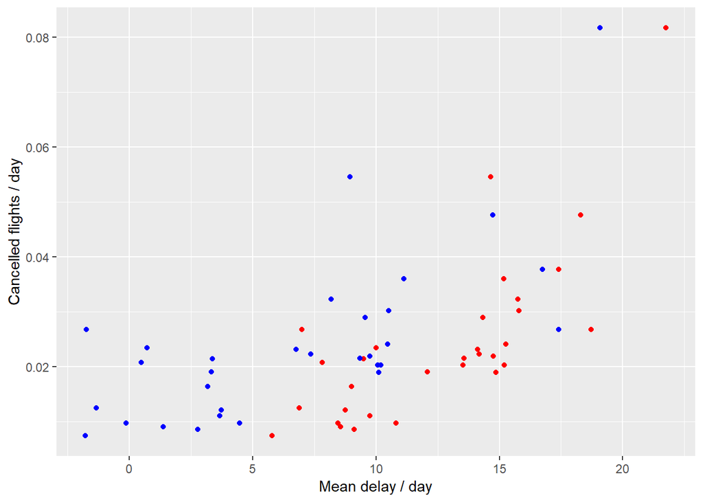

```r
flights %>%
  group_by(day) %>%
  summarise(cancelled = mean(is.na(dep_delay)),
            mean_dep_delay = mean(dep_delay, na.rm = T),
            mean_arr_delay = mean(arr_delay, na.rm = T)) %>%
  ggplot(aes(y = cancelled)) +
  geom_point(aes(x = mean_dep_delay), colour = "red") +
  geom_point(aes(x = mean_arr_delay), colour = "blue") +
  labs(x = "Mean delay / day", y = "Cancelled flights / day")
```

Clearly, flight delays increase, more flights are cancelled.

### 5. Which carrier has the worst delays?

```r
flights %>%
  group_by(carrier) %>%
  summarise(max_dep_delay = max(dep_delay, na.rm = T),
            max_arr_delay = max(arr_delay, na.rm = T)) %>%
  arrange(desc(max_dep_delay, max_arr_delay)) %>%
  filter(1:n() == 1)
```

```
## # A tibble: 1 x 3
##   carrier max_dep_delay max_arr_delay
##   <chr>           <dbl>         <dbl>
## 1 HA               1301          1272
```

### 5. What does the sort argument to count() do. When might you use it?

The sort argument sorts a grouped dataframe by the counts.

## 5.7.1 Exercises

### 1. Refer back to the table of useful mutate and filtering functions. Describe how each operation changes when you combine it with grouping.

The operation is applied on each group separately.

### 2. Which plane (tailnum) has the worst on-time record?

```r
flights %>%
  filter(!is.na(arr_delay)) %>%
  group_by(tailnum) %>%
  summarise(tot_delay = sum(arr_delay <= 30)/n(),
            mean_arr_delay = mean(arr_delay, na.rm = T),
            fl = n()) %>%
  arrange(desc(tot_delay))
```

```
## # A tibble: 4,037 x 4
##    tailnum tot_delay mean_arr_delay    fl
##    <chr>       <dbl>          <dbl> <int>
##  1 N103US          1          -6.93    46
##  2 N1200K          1          -9.38    21
##  3 N121DE          1          15        2
##  4 N137DL          1          -5        1
##  5 N143DA          1          24        1
##  6 N14628          1          -6        1
##  7 N14629          1         -16.2      4
##  8 N1607B          1         -16        3
##  9 N1608           1         -11.3      3
## 10 N1610D          1         -14.5      2
## # ... with 4,027 more rows
```

### 3. What time of day should you fly if you want to avoid delays as much as possible?

```r
flights %>%
  group_by(hour) %>%
  filter(!is.na(dep_delay)) %>%
  summarise(mean_dep_delay = mean(dep_delay > 0 , na.rm = T)) %>%
  arrange(mean_dep_delay)
```

```
## # A tibble: 19 x 2
##     hour mean_dep_delay
##    <dbl>          <dbl>
##  1     6          0.213
##  2     7          0.220
##  3     5          0.252
##  4     8          0.253
##  5     9          0.270
##  6    10          0.301
##  7    11          0.320
##  8    12          0.360
##  9    13          0.419
## 10    14          0.438
## 11    23          0.440
## 12    22          0.462
## 13    16          0.483
## 14    15          0.489
## 15    18          0.503
## 16    17          0.510
## 17    19          0.527
## 18    21          0.532
## 19    20          0.536
```

### 4. For each destination, compute the total minutes of delay. For each, flight, compute the proportion of the total delay for its destination.

```r
flights %>%
  group_by(dest) %>%
  filter(!is.na(dep_delay), dep_delay > 0) %>%
  summarise(tot_min = sum(dep_delay))
```

```
## # A tibble: 103 x 2
##    dest  tot_min
##    <chr>   <dbl>
##  1 ABQ      4076
##  2 ACK      2603
##  3 ALB     10934
##  4 ANC       105
##  5 ATL    254414
##  6 AUS     36623
##  7 AVL      3092
##  8 BDL      8471
##  9 BGR      8170
## 10 BHM      8817
## # ... with 93 more rows
```

```r
flights %>%
  filter(!is.na(dep_delay)) %>%
  group_by(tailnum, dest) %>%
  summarise(m = mean(dep_delay > 0), n = n())
```

```
## # A tibble: 44,218 x 4
## # Groups:   tailnum [4,037]
##    tailnum dest      m     n
##    <chr>   <chr> <dbl> <int>
##  1 D942DN  ATL   0.5       2
##  2 D942DN  MCO   1         2
##  3 N0EGMQ  ATL   0.233    60
##  4 N0EGMQ  BNA   0.255    51
##  5 N0EGMQ  CLE   0.308    13
##  6 N0EGMQ  CLT   0.34     50
##  7 N0EGMQ  CMH   0.471    17
##  8 N0EGMQ  DCA   0.5      12
##  9 N0EGMQ  DTW   0.174    23
## 10 N0EGMQ  MSP   0.317    41
## # ... with 44,208 more rows
```

### 5. Delays are typically temporally correlated: even once the problem that caused the initial delay has been resolved, later flights are delayed to allow earlier flights to leave. Using lag() explore how the delay of a flight is related to the delay of the immediately preceding flight.

```r
flights %>%
  select(year, month, day, hour, dest, dep_delay) %>%
  group_by(dest) %>%
  mutate(lag_delay = lag(dep_delay)) %>%
  arrange(dest) %>%
  filter(!is.na(lag_delay)) %>%
  summarize(corr = cor(dep_delay, lag_delay, use = "complete.obs"), n = n()) %>%
  arrange(desc(corr)) %>%
  filter(row_number(desc(corr)) %in% 1:10)
```

```
## # A tibble: 10 x 3
##    dest   corr     n
##    <chr> <dbl> <int>
##  1 SBN   0.687     9
##  2 ORD   0.403 16641
##  3 HDN   0.365    13
##  4 ATL   0.351 16897
##  5 SFO   0.344 13229
##  6 BZN   0.325    34
##  7 BOS   0.323 15048
##  8 FLL   0.312 11933
##  9 BNA   0.302  6104
## 10 MDW   0.296  4043
```

There is correlation between the lagged values in many of the destionatinons. The relationship is for flights headed to the same destination.

### 6. Look at each destination. Can you find flights that are suspiciously fast? (i.e. flights that represent a potential data entry error). Compute the air time a flight relative to the shortest flight to that destination. Which flights were most delayed in the air?

```r
flights %>%
  group_by(dest) %>%
  arrange(air_time) %>%
  slice(1:5) %>%
  arrange(air_time)
```

```
## # A tibble: 517 x 19
## # Groups:   dest [105]
##     year month   day dep_time sched_dep_time dep_delay arr_time
##    <int> <int> <int>    <int>          <int>     <dbl>    <int>
##  1  2013     1    16     1355           1315        40     1442
##  2  2013     4    13      537            527        10      622
##  3  2013    12     6      922            851        31     1021
##  4  2013     2     5     1303           1315       -12     1342
##  5  2013     3    18     1456           1329        87     1533
##  6  2013     3     2     1450           1500       -10     1547
##  7  2013     2     3     2153           2129        24     2247
##  8  2013     2    12     2123           2130        -7     2211
##  9  2013     3     8     2026           1935        51     2131
## 10  2013     1     6     2125           2129        -4     2224
## # ... with 507 more rows, and 12 more variables: sched_arr_time <int>,
## #   arr_delay <dbl>, carrier <chr>, flight <int>, tailnum <chr>,
## #   origin <chr>, dest <chr>, air_time <dbl>, distance <dbl>, hour <dbl>,
## #   minute <dbl>, time_hour <dttm>
```

### 7. Find all destinations that are flown by at least two carriers. Use that information to rank the carriers.

```r
flights %>%
  group_by(dest) %>%
  filter(n_distinct(carrier) >= 2) %>%
  group_by(carrier) %>%
  summarise(n = n_distinct(dest)) %>%
  arrange(-n)
```

```
## # A tibble: 16 x 2
##    carrier     n
##    <chr>   <int>
##  1 EV         51
##  2 9E         48
##  3 UA         42
##  4 DL         39
##  5 B6         35
##  6 AA         19
##  7 MQ         19
##  8 WN         10
##  9 OO          5
## 10 US          5
## 11 VX          4
## 12 YV          3
## 13 FL          2
## 14 AS          1
## 15 F9          1
## 16 HA          1
```

### 8. For each plane, count the number of flights before the first delay of greater than 1 hour.

```r
flights %>%
    mutate(dep_date = lubridate::make_datetime(year, month, day)) %>%
    group_by(tailnum) %>%
    arrange(dep_date) %>%
    filter(!cumany(arr_delay>60)) %>%
    tally(sort = TRUE)
```

```
## # A tibble: 3,748 x 2
##    tailnum     n
##    <chr>   <int>
##  1 N705TW     97
##  2 N765US     97
##  3 N12125     94
##  4 N320AA     94
##  5 N13110     91
##  6 N3763D     82
##  7 N58101     82
##  8 N17122     81
##  9 N961UW     80
## 10 N950UW     79
## # ... with 3,738 more rows
```